# Machine learning - Lab 3.1

**@author : Maelwenn LABIDURIE & Albane COIFFE**  
**@email : maelwenn.labidurie@efrei.net & albane.coiffe@efrei.net**  
18/09/2024

## **Objective**

In this lab, you will implement a Multi-Layer Perceptron (MLP) classifier using scikit-learn to classify forest cover types. You have already performed the data profiling and preprocessing steps in a previous lab, and you will now focus on building and evaluating the MLP model.

```python
from ydata_profiling import ProfileReport
import matplotlib.pyplot as plt
import seaborn as sns
import numpy as np
import pandas as pd
from sklearn.model_selection import train_test_split
from sklearn.preprocessing import StandardScaler
from sklearn.linear_model import LogisticRegression
from sklearn.multiclass import OneVsRestClassifier
from sklearn.preprocessing import StandardScaler
from sklearn.pipeline import make_pipeline
from sklearn.metrics import confusion_matrix, classification_report
from sklearn.neighbors import KNeighborsClassifier
```

```python
from sklearn.neural_network import MLPClassifier
```

## **Recap: Previous Lab**

You have already preprocessed the Forest Cover Type Dataset:

- Feature scaling using StandardScaler.
- One-hot encoding for the target variable.
- Train-test split (80% for training and 20% for testing).

```python
column_names = [
    'Elevation', 'Aspect', 'Slope', 'Horizontal_Distance_To_Hydrology',
    'Vertical_Distance_To_Hydrology', 'Horizontal_Distance_To_Roadways',
    'Hillshade_9am', 'Hillshade_Noon', 'Hillshade_3pm',
    'Horizontal_Distance_To_Fire_Points', 'Wilderness_Area1', 'Wilderness_Area2',
    'Wilderness_Area3', 'Wilderness_Area4', 'Soil_Type1', 'Soil_Type2',
    'Soil_Type3', 'Soil_Type4', 'Soil_Type5', 'Soil_Type6', 'Soil_Type7',
    'Soil_Type8', 'Soil_Type9', 'Soil_Type10', 'Soil_Type11', 'Soil_Type12',
    'Soil_Type13', 'Soil_Type14', 'Soil_Type15', 'Soil_Type16', 'Soil_Type17',
    'Soil_Type18', 'Soil_Type19', 'Soil_Type20', 'Soil_Type21', 'Soil_Type22',
    'Soil_Type23', 'Soil_Type24', 'Soil_Type25', 'Soil_Type26', 'Soil_Type27',
    'Soil_Type28', 'Soil_Type29', 'Soil_Type30', 'Soil_Type31', 'Soil_Type32',
    'Soil_Type33', 'Soil_Type34', 'Soil_Type35', 'Soil_Type36', 'Soil_Type37',
    'Soil_Type38', 'Soil_Type39', 'Soil_Type40', 'Cover_Type'
]
df = pd.read_csv('covtype.data', names=column_names, header=None)
```

```python
outliers_conditions = {
    'Slope': df['Slope'] > 40,
    'Horizontal_Distance_To_Hydrology': df['Horizontal_Distance_To_Hydrology'] > 1000,
    'Vertical_Distance_To_Hydrology': (df['Vertical_Distance_To_Hydrology'] > 300) |
                                     (df['Vertical_Distance_To_Hydrology'] < -100),
    'Hillshade_9am': df['Hillshade_9am'] < 100,
    'Hillshade_Noon': df['Hillshade_Noon'] < 150
}

outlier_conditions_combined = pd.concat(outliers_conditions.values(), axis=1).any(axis=1)

df_cleaned = df[~outlier_conditions_combined]
```

```python
columns_to_drop = [
    'Soil_Type1', 'Soil_Type2', 'Soil_Type3', 'Soil_Type4', 'Soil_Type5', 'Soil_Type6',
    'Soil_Type7', 'Soil_Type8', 'Soil_Type9', 'Soil_Type10', 'Soil_Type11', 'Soil_Type12',
    'Soil_Type13', 'Soil_Type14', 'Soil_Type15', 'Soil_Type16', 'Soil_Type17',
    'Soil_Type18', 'Soil_Type19', 'Soil_Type20', 'Soil_Type21', 'Soil_Type22',
    'Soil_Type24', 'Soil_Type25', 'Soil_Type26', 'Soil_Type27', 'Soil_Type28',
    'Soil_Type30', 'Soil_Type31', 'Soil_Type32', 'Soil_Type33', 'Soil_Type34',
    'Soil_Type35', 'Soil_Type36', 'Soil_Type37', 'Soil_Type38', 'Soil_Type39',
    'Soil_Type40', 'Wilderness_Area2'
]

df_cleaned = df_cleaned.drop(columns=columns_to_drop, errors='ignore')
```

```python
df_cleaned.head()
```

|  | Elevation | Aspect | Slope | Horizontal_Distance_To_Hydrology | Vertical_Distance_To_Hydrology | Horizontal_Distance_To_Roadways | Hillshade_9am | Hillshade_Noon | Hillshade_3pm | Horizontal_Distance_To_Fire_Points | Wilderness_Area1 | Wilderness_Area3 | Wilderness_Area4 | Soil_Type23 | Soil_Type29 | Cover_Type |
| --- | --- | --- | --- | --- | --- | --- | --- | --- | --- | --- | --- | --- | --- | --- | --- | --- |
| 0 | 2596 | 51 | 3 | 258 | 0 | 510 | 221 | 232 | 148 | 6279 | 1 | 0 | 0 | 0 | 1 | 5 |
| 1 | 2590 | 56 | 2 | 212 | -6 | 390 | 220 | 235 | 151 | 6225 | 1 | 0 | 0 | 0 | 1 | 5 |
| 2 | 2804 | 139 | 9 | 268 | 65 | 3180 | 234 | 238 | 135 | 6121 | 1 | 0 | 0 | 0 | 0 | 2 |
| 3 | 2785 | 155 | 18 | 242 | 118 | 3090 | 238 | 238 | 122 | 6211 | 1 | 0 | 0 | 0 | 0 | 2 |
| 4 | 2595 | 45 | 2 | 153 | -1 | 391 | 220 | 234 | 150 | 6172 | 1 | 0 | 0 | 0 | 1 | 5 |

```python
X = df_cleaned.drop(columns='Cover_Type')
y = df_cleaned['Cover_Type']
```

```python
X_train, X_test, y_train, y_test = train_test_split(X, y, test_size=0.2, random_state=42)
```

```python
# Feature scaling using StandardScaler
scaler = StandardScaler()
X_train_scaled = scaler.fit_transform(X_train)
X_test_scaled = scaler.transform(X_test)
```

```python
# one hot encoding
y_train_hot = pd.get_dummies(y_train)
y_test_hot = pd.get_dummies(y_test)
```

```python
df_cleaned.head()
```

|  | Elevation | Aspect | Slope | Horizontal_Distance_To_Hydrology | Vertical_Distance_To_Hydrology | Horizontal_Distance_To_Roadways | Hillshade_9am | Hillshade_Noon | Hillshade_3pm | Horizontal_Distance_To_Fire_Points | Wilderness_Area1 | Wilderness_Area3 | Wilderness_Area4 | Soil_Type23 | Soil_Type29 | Cover_Type |
| --- | --- | --- | --- | --- | --- | --- | --- | --- | --- | --- | --- | --- | --- | --- | --- | --- |
| 0 | 2596 | 51 | 3 | 258 | 0 | 510 | 221 | 232 | 148 | 6279 | 1 | 0 | 0 | 0 | 1 | 5 |
| 1 | 2590 | 56 | 2 | 212 | -6 | 390 | 220 | 235 | 151 | 6225 | 1 | 0 | 0 | 0 | 1 | 5 |
| 2 | 2804 | 139 | 9 | 268 | 65 | 3180 | 234 | 238 | 135 | 6121 | 1 | 0 | 0 | 0 | 0 | 2 |
| 3 | 2785 | 155 | 18 | 242 | 118 | 3090 | 238 | 238 | 122 | 6211 | 1 | 0 | 0 | 0 | 0 | 2 |
| 4 | 2595 | 45 | 2 | 153 | -1 | 391 | 220 | 234 | 150 | 6172 | 1 | 0 | 0 | 0 | 1 | 5 |

## **Build the MLP Classifier using scikit-learn**

### 1. Import the MLPClassifier

### 2. Define the MLP Model

```python
# Define the MLP model with two hidden layers (128, 64 neurons)
mlp = MLPClassifier(hidden_layer_sizes=(128, 64), activation='relu', solver='adam',
max_iter=200, random_state=42)
```

### 3. Train the MLP Model:

```python
import numpy as np

# Convert y_train to a NumPy array if it's not already
y_train_np = np.array(y_train_hot)

# Ensure y_train_np is a 2D array
if y_train_np.ndim == 1:
    y_train_np = y_train_np.reshape(-1, 1)

# Use integer-encoded labels for training
mlp.fit(X_train_scaled, y_train_np.argmax(axis=1))
```

```
MLPClassifier(hidden_layer_sizes=(128, 64), random_state=42)
```

### 4. Evaluate the Model:

```python
# Convert y_test to a NumPy array if it's not already
y_test_np = np.array(y_test_hot)

# Ensure y_test_np is a 2D array
if y_test_np.ndim == 1:
    y_test_np = y_test_np.reshape(-1, 1)

# Make predictions
y_pred_mlp = mlp.predict(X_test_scaled)

# Evaluate the model
# Print classification report
print('Classification Report (MLP Classifier):\n',
      classification_report(y_test_np.argmax(axis=1), y_pred_mlp))

# Confusion matrix
cm_mlp = confusion_matrix(y_test_np.argmax(axis=1), y_pred_mlp)
print('Confusion Matrix (MLP Classifier):\n', cm_mlp)
```

```
Classification Report (MLP Classifier):
               precision    recall  f1-score   support

           0       0.89      0.92      0.90     42186
           1       0.93      0.90      0.91     55563
           2       0.92      0.88      0.90      6866
           3       0.82      0.86      0.84       516
           4       0.79      0.70      0.74      1906
           5       0.78      0.87      0.82      3374
           6       0.92      0.91      0.92      3847

    accuracy                           0.90    114258
   macro avg       0.86      0.86      0.86    114258
weighted avg       0.90      0.90      0.90    114258

Confusion Matrix (MLP Classifier):
 [[38807  3049     2     0    36    20   272]
 [ 4624 50175   165     8   290   268    33]
 [    1   285  6021    63    20   476     0]
 [    0     0    48   443     0    25     0]
 [  100   426    26     0  1329    25     0]
 [    8   134   262    28     4  2938     0]
 [  289    41     0     0     0     0  3517]]
```

### 5. Visualize the Confusion Matrix:

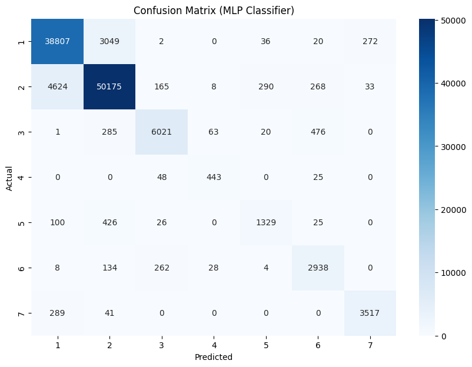

```python
import seaborn as sns
import matplotlib.pyplot as plt
# Plot confusion matrix
plt.figure(figsize=(10,7))
sns.heatmap(cm_mlp, annot=True, fmt='d', cmap='Blues', xticklabels=np.arange(1, 8),
yticklabels=np.arange(1, 8))
plt.xlabel('Predicted')
plt.ylabel('Actual')
plt.title('Confusion Matrix (MLP Classifier)')
plt.show()
```

### 6. Experiment with Hyperparameters:

```python
# Define a new MLP model with different hyperparameters
mlp_tuned = MLPClassifier(hidden_layer_sizes=(128, 64), activation='relu',
solver='adam', max_iter=200, alpha=0.001, learning_rate_init=0.001, random_state=42)
# Train the tuned model
mlp_tuned.fit(X_train_scaled, y_train_np.argmax(axis=1))
# Predict and evaluate the tuned model
y_pred_tuned = mlp_tuned.predict(X_test_scaled)
print('Classification Report (Tuned MLP Classifier):\n',
classification_report(y_test_np.argmax(axis=1), y_pred_tuned))
```

```
Classification Report (Tuned MLP Classifier):
               precision    recall  f1-score   support

           0       0.89      0.90      0.90     42186
           1       0.92      0.91      0.91     55563
           2       0.91      0.86      0.89      6866
           3       0.81      0.83      0.82       516
           4       0.85      0.66      0.75      1906
           5       0.81      0.84      0.83      3374
           6       0.89      0.93      0.91      3847

    accuracy                           0.90    114258
   macro avg       0.87      0.85      0.86    114258
weighted avg       0.90      0.90      0.90    114258
```

## **Analysis and Discussion**

### 1 - Compare Performance:

Compare the results from the MLPClassifier with previous models (e.g., Logistic Regression or k-NN). Discuss which model performed better for the dataset and why.

[figure not shown]

Premiere matrice : Modele de regression  
Deuxieme matrice : Modele de KNN

Le modèle de régression logistique et le KNN sont nettement moins précis par rapport à notre autre modèle, le MLP (Multi-Layer Perceptron).

Pour le type 1 :

- Le modèle de régression logistique et le KNN prédissent correctement 29 213 cas, contre 38 807 pour le MLP.
- En termes d'erreurs pour le type 1, le modèle de régression et de KNN font 13 859 erreurs tous types confondus, tandis que le MLP n'en fait que 5 022.
- Cela représente 2,75 fois plus d'erreurs pour le modèle de régression logistique et de KNN dans la prédiction du type 1 par rapport au MLP.

Pour le type 2 :

- Le modèle de régression logistique et le KNN prédissent correctement 44 644 cas, contre 50 175 pour le MLP.
- En termes d'erreurs, le modèle de régression et de KNN font 19 224 erreurs pour le type 2, contre 3 935 erreurs pour le MLP.
- Cela représente 4,8 fois plus d'erreurs pour la prédiction du type 2 avec le modèle de régression et de KNN par rapport au MLP.

### 2. Experiment with Hyperparameters:

#### **Expérimentation 1**

##### **Explication du choix des hyperparametres :**

Pour ces nouveaux hyperparamètres, nous avons ajouté une couche et augmenté le nombre d'itérations.

- Nous avons ajouté une couche pour augmenter la précision du modèle. Cela permet de détecter plus précisément les liens entre les différentes données de train.
- Pour les itérations, nous en avons ajouté 50. Cela permet une meilleure convergence vers un modèle plus juste, ainsi qu'une optimisation plus précise. Cependant, il y a un plus grand risque d'overfitting, qui fausserait les résultats du modèle.

```python
# Define a new MLP model with different hyperparameters
mlp_tuned = MLPClassifier(hidden_layer_sizes=(128, 64, 32), activation='relu',
solver='adam', max_iter=250, alpha=0.001, learning_rate_init=0.001, random_state=42)
# Train the tuned model
mlp_tuned.fit(X_train_scaled, y_train_np.argmax(axis=1))
# Predict and evaluate the tuned model
y_pred_tuned = mlp_tuned.predict(X_test_scaled)
print('Classification Report (Tuned MLP Classifier):\n',
classification_report(y_test_np.argmax(axis=1), y_pred_tuned))
```

```
Classification Report (Tuned MLP Classifier):
               precision    recall  f1-score   support

           0       0.94      0.90      0.92     42186
           1       0.91      0.95      0.93     55563
           2       0.94      0.87      0.90      6866
           3       0.80      0.83      0.82       516
           4       0.84      0.71      0.77      1906
           5       0.77      0.90      0.83      3374
           6       0.94      0.91      0.93      3847

    accuracy                           0.92    114258
   macro avg       0.88      0.87      0.87    114258
weighted avg       0.92      0.92      0.92    114258
```

##### **Comparaison avec les hyperparametres originaux :**

L'accuracy du modèle est également plus élevée avec 3 couches et 250 itérations, passant de 90 à 92.

#### **Expérimentation 2**

##### **Explication du choix des hyperparametres :**

Pour ces nouveaux hyperparamètres, nous a réduit le nombre de neuronne par couche et diminué le nombre d'itérations par rapport aux hyperparamètres originaux.

- Nous avons réduit le nombre de neurones par couche afin d'évaluer son impact sur le modèle. Cette réduction devrait entraîner une baisse de la précision.
- Concernant le nombre d'itérations, nous avons diminué de 50 par rapport aux hyperparamètres initiaux. Cette modification pourrait entraîner une convergence moins optimale du modèle, potentiellement affectant ses performances.

```python
# Define a new MLP model with different hyperparameters
mlp_tuned = MLPClassifier(hidden_layer_sizes=(64, 32), activation='relu',
solver='adam', max_iter=150, alpha=0.001, learning_rate_init=0.001, random_state=42)
# Train the tuned model
mlp_tuned.fit(X_train_scaled, y_train_np.argmax(axis=1))
# Predict and evaluate the tuned model
y_pred_tuned = mlp_tuned.predict(X_test_scaled)
print('Classification Report (Tuned MLP Classifier):\n',
classification_report(y_test_np.argmax(axis=1), y_pred_tuned))
```

```
Classification Report (Tuned MLP Classifier):
               precision    recall  f1-score   support

           0       0.85      0.87      0.86     42186
           1       0.88      0.88      0.88     55563
           2       0.82      0.83      0.83      6866
           3       0.81      0.75      0.77       516
           4       0.70      0.51      0.59      1906
           5       0.74      0.69      0.71      3374
           6       0.89      0.84      0.86      3847

    accuracy                           0.86    114258
   macro avg       0.81      0.77      0.79    114258
weighted avg       0.86      0.86      0.86    114258
```

##### **Comparaison avec les hyperparametres originaux :**

L'accuracy du modèle est également plus faible avec moins de neurones par couche et uniquement 150 itérations, passant de 90 à 86.